# Risk Factor Analysis

## Outcome Variable

**Outcome Variable:** ever_stunted

## Predictor Variables

**Intervention Variable:** single

**Adjustment Set:**

- arm
- W_mage
- meducyrs
- feducyrs
- W_mhtcm
- W_mwtkg
- W_mbmi
- delta_W_mage
- delta_meducyrs
- delta_feducyrs
- delta_W_mhtcm
- delta_W_mwtkg
- delta_W_mbmi

## Stratifying Variables

The analysis was stratified on these variable(s):

- agecat
- studyid
- country

## Data Summary

| agecat | studyid | country | single | ever_stunted | n_cell | n |
| --- | --- | --- | --- | --- | --- | --- |
| 0-24 months | ki0047075b-MAL-ED | BANGLADESH | 0 | 0 | 103 | 265 |
| 0-24 months | ki0047075b-MAL-ED | BANGLADESH | 0 | 1 | 162 | 265 |
| 0-24 months | ki0047075b-MAL-ED | BANGLADESH | 1 | 0 | 0 | 265 |
| 0-24 months | ki0047075b-MAL-ED | BANGLADESH | 1 | 1 | 0 | 265 |
| 0-24 months | ki0047075b-MAL-ED | BRAZIL | 0 | 0 | 148 | 233 |
| 0-24 months | ki0047075b-MAL-ED | BRAZIL | 0 | 1 | 49 | 233 |
| 0-24 months | ki0047075b-MAL-ED | BRAZIL | 1 | 0 | 22 | 233 |
| 0-24 months | ki0047075b-MAL-ED | BRAZIL | 1 | 1 | 14 | 233 |
| 0-24 months | ki0047075b-MAL-ED | INDIA | 0 | 0 | 99 | 249 |
| 0-24 months | ki0047075b-MAL-ED | INDIA | 0 | 1 | 150 | 249 |
| 0-24 months | ki0047075b-MAL-ED | INDIA | 1 | 0 | 0 | 249 |
| 0-24 months | ki0047075b-MAL-ED | INDIA | 1 | 1 | 0 | 249 |
| 0-24 months | ki0047075b-MAL-ED | NEPAL | 0 | 0 | 156 | 240 |
| 0-24 months | ki0047075b-MAL-ED | NEPAL | 0 | 1 | 84 | 240 |
| 0-24 months | ki0047075b-MAL-ED | NEPAL | 1 | 0 | 0 | 240 |
| 0-24 months | ki0047075b-MAL-ED | NEPAL | 1 | 1 | 0 | 240 |
| 0-24 months | ki0047075b-MAL-ED | PERU | 0 | 0 | 101 | 303 |
| 0-24 months | ki0047075b-MAL-ED | PERU | 0 | 1 | 167 | 303 |
| 0-24 months | ki0047075b-MAL-ED | PERU | 1 | 0 | 14 | 303 |
| 0-24 months | ki0047075b-MAL-ED | PERU | 1 | 1 | 21 | 303 |
| 0-24 months | ki0047075b-MAL-ED | SOUTH AFRICA | 0 | 0 | 79 | 314 |
| 0-24 months | ki0047075b-MAL-ED | SOUTH AFRICA | 0 | 1 | 97 | 314 |
| 0-24 months | ki0047075b-MAL-ED | SOUTH AFRICA | 1 | 0 | 59 | 314 |
| 0-24 months | ki0047075b-MAL-ED | SOUTH AFRICA | 1 | 1 | 79 | 314 |
| 0-24 months | ki0047075b-MAL-ED | TANZANIA, UNITED REPUBLIC OF | 0 | 0 | 37 | 262 |
| 0-24 months | ki0047075b-MAL-ED | TANZANIA, UNITED REPUBLIC OF | 0 | 1 | 215 | 262 |
| 0-24 months | ki0047075b-MAL-ED | TANZANIA, UNITED REPUBLIC OF | 1 | 0 | 3 | 262 |
| 0-24 months | ki0047075b-MAL-ED | TANZANIA, UNITED REPUBLIC OF | 1 | 1 | 7 | 262 |
| 0-24 months | ki1066203-TanzaniaChild2 | TANZANIA, UNITED REPUBLIC OF | 0 | 0 | 1400 | 2375 |
| 0-24 months | ki1066203-TanzaniaChild2 | TANZANIA, UNITED REPUBLIC OF | 0 | 1 | 751 | 2375 |

[output cut: 150 more lines]

The following strata were considered:

- agecat: 0-24 months, studyid: ki0047075b-MAL-ED, country: BANGLADESH
- agecat: 0-24 months, studyid: ki0047075b-MAL-ED, country: BRAZIL
- agecat: 0-24 months, studyid: ki0047075b-MAL-ED, country: INDIA
- agecat: 0-24 months, studyid: ki0047075b-MAL-ED, country: NEPAL
- agecat: 0-24 months, studyid: ki0047075b-MAL-ED, country: PERU
- agecat: 0-24 months, studyid: ki0047075b-MAL-ED, country: SOUTH AFRICA
- agecat: 0-24 months, studyid: ki0047075b-MAL-ED, country: TANZANIA, UNITED REPUBLIC OF
- agecat: 0-24 months, studyid: ki1066203-TanzaniaChild2, country: TANZANIA, UNITED REPUBLIC OF
- agecat: 0-24 months, studyid: ki1112895-Guatemala BSC, country: GUATEMALA
- agecat: 0-24 months, studyid: ki1119695-PROBIT, country: BELARUS
- agecat: 0-24 months, studyid: ki1126311-ZVITAMBO, country: ZIMBABWE
- agecat: 0-24 months, studyid: ki1135781-COHORTS, country: GUATEMALA
- agecat: 0-24 months, studyid: ki1135781-COHORTS, country: INDIA
- agecat: 0-24 months, studyid: ki1135781-COHORTS, country: PHILIPPINES
- agecat: 0-24 months, studyid: kiGH5241-JiVitA-4, country: BANGLADESH
- agecat: 0-6 months, studyid: ki0047075b-MAL-ED, country: BANGLADESH
- agecat: 0-6 months, studyid: ki0047075b-MAL-ED, country: BRAZIL
- agecat: 0-6 months, studyid: ki0047075b-MAL-ED, country: INDIA
- agecat: 0-6 months, studyid: ki0047075b-MAL-ED, country: NEPAL
- agecat: 0-6 months, studyid: ki0047075b-MAL-ED, country: PERU
- agecat: 0-6 months, studyid: ki0047075b-MAL-ED, country: SOUTH AFRICA
- agecat: 0-6 months, studyid: ki0047075b-MAL-ED, country: TANZANIA, UNITED REPUBLIC OF
- agecat: 0-6 months, studyid: ki1066203-TanzaniaChild2, country: TANZANIA, UNITED REPUBLIC OF
- agecat: 0-6 months, studyid: ki1112895-Guatemala BSC, country: GUATEMALA
- agecat: 0-6 months, studyid: ki1119695-PROBIT, country: BELARUS
- agecat: 0-6 months, studyid: ki1126311-ZVITAMBO, country: ZIMBABWE
- agecat: 0-6 months, studyid: ki1135781-COHORTS, country: GUATEMALA
- agecat: 0-6 months, studyid: ki1135781-COHORTS, country: INDIA
- agecat: 0-6 months, studyid: ki1135781-COHORTS, country: PHILIPPINES
- agecat: 0-6 months, studyid: kiGH5241-JiVitA-4, country: BANGLADESH
- agecat: 6-24 months, studyid: ki0047075b-MAL-ED, country: BANGLADESH
- agecat: 6-24 months, studyid: ki0047075b-MAL-ED, country: BRAZIL
- agecat: 6-24 months, studyid: ki0047075b-MAL-ED, country: INDIA
- agecat: 6-24 months, studyid: ki0047075b-MAL-ED, country: NEPAL
- agecat: 6-24 months, studyid: ki0047075b-MAL-ED, country: PERU
- agecat: 6-24 months, studyid: ki0047075b-MAL-ED, country: SOUTH AFRICA
- agecat: 6-24 months, studyid: ki0047075b-MAL-ED, country: TANZANIA, UNITED REPUBLIC OF
- agecat: 6-24 months, studyid: ki1066203-TanzaniaChild2, country: TANZANIA, UNITED REPUBLIC OF
- agecat: 6-24 months, studyid: ki1112895-Guatemala BSC, country: GUATEMALA
- agecat: 6-24 months, studyid: ki1119695-PROBIT, country: BELARUS
- agecat: 6-24 months, studyid: ki1126311-ZVITAMBO, country: ZIMBABWE
- agecat: 6-24 months, studyid: ki1135781-COHORTS, country: GUATEMALA
- agecat: 6-24 months, studyid: ki1135781-COHORTS, country: INDIA
- agecat: 6-24 months, studyid: ki1135781-COHORTS, country: PHILIPPINES
- agecat: 6-24 months, studyid: kiGH5241-JiVitA-4, country: BANGLADESH

### Dropped Strata

Some strata were dropped due to rare outcomes:

- agecat: 0-24 months, studyid: ki0047075b-MAL-ED, country: BANGLADESH
- agecat: 0-24 months, studyid: ki0047075b-MAL-ED, country: INDIA
- agecat: 0-24 months, studyid: ki0047075b-MAL-ED, country: NEPAL
- agecat: 0-24 months, studyid: ki0047075b-MAL-ED, country: TANZANIA, UNITED REPUBLIC OF
- agecat: 0-24 months, studyid: ki1135781-COHORTS, country: INDIA
- agecat: 0-24 months, studyid: kiGH5241-JiVitA-4, country: BANGLADESH
- agecat: 0-6 months, studyid: ki0047075b-MAL-ED, country: BANGLADESH
- agecat: 0-6 months, studyid: ki0047075b-MAL-ED, country: INDIA
- agecat: 0-6 months, studyid: ki0047075b-MAL-ED, country: NEPAL
- agecat: 0-6 months, studyid: ki0047075b-MAL-ED, country: TANZANIA, UNITED REPUBLIC OF
- agecat: 0-6 months, studyid: ki1135781-COHORTS, country: INDIA
- agecat: 0-6 months, studyid: kiGH5241-JiVitA-4, country: BANGLADESH
- agecat: 6-24 months, studyid: ki0047075b-MAL-ED, country: BANGLADESH
- agecat: 6-24 months, studyid: ki0047075b-MAL-ED, country: BRAZIL
- agecat: 6-24 months, studyid: ki0047075b-MAL-ED, country: INDIA
- agecat: 6-24 months, studyid: ki0047075b-MAL-ED, country: NEPAL
- agecat: 6-24 months, studyid: ki0047075b-MAL-ED, country: TANZANIA, UNITED REPUBLIC OF
- agecat: 6-24 months, studyid: ki1135781-COHORTS, country: INDIA
- agecat: 6-24 months, studyid: kiGH5241-JiVitA-4, country: BANGLADESH

## Methods Detail

We’re interested in the causal parameters $E[Y_a]$ for all values of $a \in \mathcal{A}$. These parameters represent the mean outcome if, possibly contrary to fact, we intervened to set all units to have $A=a$. Under the randomization and positivity assumptions, these are identified by the statistical parameters $\psi_a=E_W[E_{Y|A,W}(Y|A=a,W)]$. In addition, we’re interested in the mean of $Y$, $E[Y]$ under no intervention (the observed mean). We will estimate these parameters by using SuperLearner to fit the relevant likelihood factors – $E_{Y|A,W}(Y|A=a,W)$ and $p(A=a|W)$, and then updating our likelihood fit using a joint TMLE.

For unadjusted analyses ($W=\{\}$), initial likelihoods were estimated using Lrnr_glm to estimate the simple $E(Y|A)$ and Lrnr_mean to estimate $p(A)$. For adjusted analyses, a small library containing Lrnr_glmnet, Lrnr_xgboost, and Lrnr_mean was used.

Having estimated these parameters, we will then use the delta method to estimate relative risks and attributable risks relative to a prespecified baseline level of $A$.

# Results Detail

## Results Plots

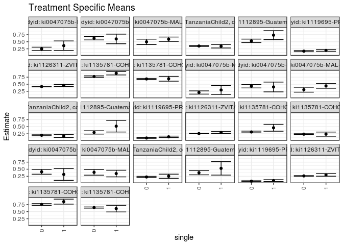

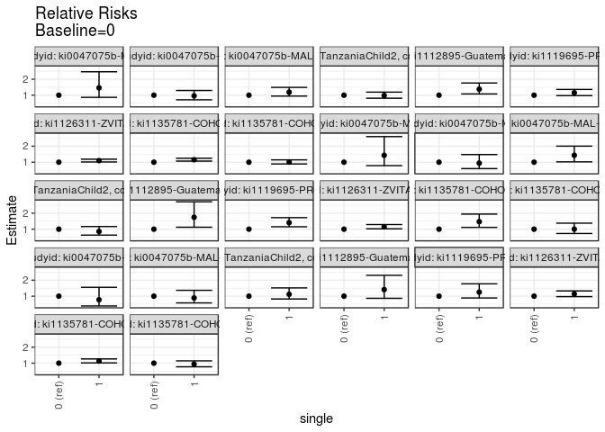

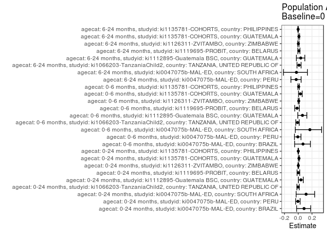

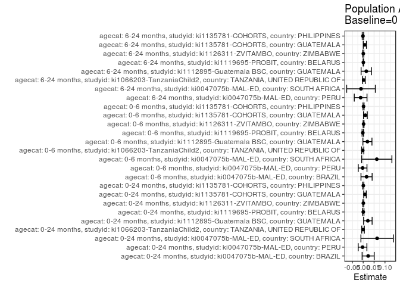

## Results Table

### Parameter: TSM

| agecat | studyid | country | intervention_level | baseline_level | estimate | ci_lower | ci_upper |
| --- | --- | --- | --- | --- | --- | --- | --- |
| 0-24 months | ki0047075b-MAL-ED | BRAZIL | 0 | NA | 0.2475794 | 0.1870350 | 0.3081239 |
| 0-24 months | ki0047075b-MAL-ED | BRAZIL | 1 | NA | 0.3617975 | 0.1947973 | 0.5287977 |
| 0-24 months | ki0047075b-MAL-ED | PERU | 0 | NA | 0.6234106 | 0.5652364 | 0.6815848 |
| 0-24 months | ki0047075b-MAL-ED | PERU | 1 | NA | 0.5989687 | 0.4287461 | 0.7691914 |
| 0-24 months | ki0047075b-MAL-ED | SOUTH AFRICA | 0 | NA | 0.4965682 | 0.4014157 | 0.5917208 |
| 0-24 months | ki0047075b-MAL-ED | SOUTH AFRICA | 1 | NA | 0.5894391 | 0.5126128 | 0.6662653 |
| 0-24 months | ki1066203-TanzaniaChild2 | TANZANIA, UNITED REPUBLIC OF | 0 | NA | 0.3488173 | 0.3286922 | 0.3689425 |
| 0-24 months | ki1066203-TanzaniaChild2 | TANZANIA, UNITED REPUBLIC OF | 1 | NA | 0.3429178 | 0.2797407 | 0.4060949 |
| 0-24 months | ki1112895-Guatemala BSC | GUATEMALA | 0 | NA | 0.5317460 | 0.4700280 | 0.5934641 |
| 0-24 months | ki1112895-Guatemala BSC | GUATEMALA | 1 | NA | 0.7333333 | 0.5748097 | 0.8918569 |
| 0-24 months | ki1119695-PROBIT | BELARUS | 0 | NA | 0.1670611 | 0.1473972 | 0.1867251 |
| 0-24 months | ki1119695-PROBIT | BELARUS | 1 | NA | 0.1925265 | 0.1635147 | 0.2215383 |
| 0-24 months | ki1126311-ZVITAMBO | ZIMBABWE | 0 | NA | 0.4165825 | 0.4081372 | 0.4250279 |
| 0-24 months | ki1126311-ZVITAMBO | ZIMBABWE | 1 | NA | 0.4572164 | 0.4217909 | 0.4926419 |
| 0-24 months | ki1135781-COHORTS | GUATEMALA | 0 | NA | 0.7713755 | 0.7466460 | 0.7961050 |
| 0-24 months | ki1135781-COHORTS | GUATEMALA | 1 | NA | 0.8896569 | 0.8278668 | 0.9514471 |
| 0-24 months | ki1135781-COHORTS | PHILIPPINES | 0 | NA | 0.6862682 | 0.6693966 | 0.7031398 |
| 0-24 months | ki1135781-COHORTS | PHILIPPINES | 1 | NA | 0.6933321 | 0.6080810 | 0.7785832 |
| 0-6 months | ki0047075b-MAL-ED | BRAZIL | 0 | NA | 0.2077257 | 0.1508284 | 0.2646229 |
| 0-6 months | ki0047075b-MAL-ED | BRAZIL | 1 | NA | 0.2967785 | 0.1389816 | 0.4545754 |
| 0-6 months | ki0047075b-MAL-ED | PERU | 0 | NA | 0.4283687 | 0.3690487 | 0.4876888 |
| 0-6 months | ki0047075b-MAL-ED | PERU | 1 | NA | 0.4030403 | 0.2297090 | 0.5763716 |
| 0-6 months | ki0047075b-MAL-ED | SOUTH AFRICA | 0 | NA | 0.3069573 | 0.2197238 | 0.3941908 |
| 0-6 months | ki0047075b-MAL-ED | SOUTH AFRICA | 1 | NA | 0.4397371 | 0.3575072 | 0.5219670 |
| 0-6 months | ki1066203-TanzaniaChild2 | TANZANIA, UNITED REPUBLIC OF | 0 | NA | 0.1977762 | 0.1809404 | 0.2146119 |
| 0-6 months | ki1066203-TanzaniaChild2 | TANZANIA, UNITED REPUBLIC OF | 1 | NA | 0.1693579 | 0.1191142 | 0.2196016 |
| 0-6 months | ki1112895-Guatemala BSC | GUATEMALA | 0 | NA | 0.2975307 | 0.2391130 | 0.3559483 |
| 0-6 months | ki1112895-Guatemala BSC | GUATEMALA | 1 | NA | 0.5192101 | 0.3127942 | 0.7256260 |
| 0-6 months | ki1119695-PROBIT | BELARUS | 0 | NA | 0.1011815 | 0.0874849 | 0.1148781 |
| 0-6 months | ki1119695-PROBIT | BELARUS | 1 | NA | 0.1424338 | 0.1161987 | 0.1686689 |
| 0-6 months | ki1126311-ZVITAMBO | ZIMBABWE | 0 | NA | 0.2569987 | 0.2494933 | 0.2645041 |
| 0-6 months | ki1126311-ZVITAMBO | ZIMBABWE | 1 | NA | 0.2949360 | 0.2616167 | 0.3282554 |
| 0-6 months | ki1135781-COHORTS | GUATEMALA | 0 | NA | 0.3142953 | 0.2840714 | 0.3445191 |
| 0-6 months | ki1135781-COHORTS | GUATEMALA | 1 | NA | 0.4624164 | 0.3401661 | 0.5846667 |
| 0-6 months | ki1135781-COHORTS | PHILIPPINES | 0 | NA | 0.2370460 | 0.2215915 | 0.2525004 |
| 0-6 months | ki1135781-COHORTS | PHILIPPINES | 1 | NA | 0.2378088 | 0.1638660 | 0.3117516 |
| 6-24 months | ki0047075b-MAL-ED | PERU | 0 | NA | 0.4076923 | 0.3229347 | 0.4924499 |
| 6-24 months | ki0047075b-MAL-ED | PERU | 1 | NA | 0.3157895 | 0.1060755 | 0.5255034 |
| 6-24 months | ki0047075b-MAL-ED | SOUTH AFRICA | 0 | NA | 0.3897288 | 0.2892948 | 0.4901627 |
| 6-24 months | ki0047075b-MAL-ED | SOUTH AFRICA | 1 | NA | 0.3460816 | 0.2281782 | 0.4639851 |
| 6-24 months | ki1066203-TanzaniaChild2 | TANZANIA, UNITED REPUBLIC OF | 0 | NA | 0.2250607 | 0.2035107 | 0.2466107 |
| 6-24 months | ki1066203-TanzaniaChild2 | TANZANIA, UNITED REPUBLIC OF | 1 | NA | 0.2515562 | 0.1784552 | 0.3246571 |
| 6-24 months | ki1112895-Guatemala BSC | GUATEMALA | 0 | NA | 0.3750000 | 0.3015949 | 0.4484051 |
| 6-24 months | ki1112895-Guatemala BSC | GUATEMALA | 1 | NA | 0.5294118 | 0.2914989 | 0.7673246 |
| 6-24 months | ki1119695-PROBIT | BELARUS | 0 | NA | 0.0760978 | 0.0619838 | 0.0902119 |
| 6-24 months | ki1119695-PROBIT | BELARUS | 1 | NA | 0.0953053 | 0.0629920 | 0.1276187 |
| 6-24 months | ki1126311-ZVITAMBO | ZIMBABWE | 0 | NA | 0.2623964 | 0.2527122 | 0.2720806 |
| 6-24 months | ki1126311-ZVITAMBO | ZIMBABWE | 1 | NA | 0.2978676 | 0.2525305 | 0.3432047 |
| 6-24 months | ki1135781-COHORTS | GUATEMALA | 0 | NA | 0.7546174 | 0.7239651 | 0.7852698 |
| 6-24 months | ki1135781-COHORTS | GUATEMALA | 1 | NA | 0.8548387 | 0.7671013 | 0.9425761 |
| 6-24 months | ki1135781-COHORTS | PHILIPPINES | 0 | NA | 0.6462512 | 0.6254369 | 0.6670656 |
| 6-24 months | ki1135781-COHORTS | PHILIPPINES | 1 | NA | 0.6080987 | 0.4906461 | 0.7255513 |

### Parameter: E(Y)

| agecat | studyid | country | intervention_level | baseline_level | estimate | ci_lower | ci_upper |
| --- | --- | --- | --- | --- | --- | --- | --- |
| 0-24 months | ki0047075b-MAL-ED | BRAZIL | NA | NA | 0.2703863 | 0.2132328 | 0.3275398 |
| 0-24 months | ki0047075b-MAL-ED | PERU | NA | NA | 0.6204620 | 0.5657315 | 0.6751926 |
| 0-24 months | ki0047075b-MAL-ED | SOUTH AFRICA | NA | NA | 0.5605096 | 0.5055248 | 0.6154943 |
| 0-24 months | ki1066203-TanzaniaChild2 | TANZANIA, UNITED REPUBLIC OF | NA | NA | 0.3482105 | 0.3290467 | 0.3673744 |
| 0-24 months | ki1112895-Guatemala BSC | GUATEMALA | NA | NA | 0.5531915 | 0.4950624 | 0.6113206 |
| 0-24 months | ki1119695-PROBIT | BELARUS | NA | NA | 0.1674854 | 0.1488048 | 0.1861659 |
| 0-24 months | ki1126311-ZVITAMBO | ZIMBABWE | NA | NA | 0.4172374 | 0.4090737 | 0.4254012 |
| 0-24 months | ki1135781-COHORTS | GUATEMALA | NA | NA | 0.7796189 | 0.7562250 | 0.8030128 |
| 0-24 months | ki1135781-COHORTS | PHILIPPINES | NA | NA | 0.6868787 | 0.6703303 | 0.7034272 |
| 0-6 months | ki0047075b-MAL-ED | BRAZIL | NA | NA | 0.2231760 | 0.1695976 | 0.2767543 |
| 0-6 months | ki0047075b-MAL-ED | PERU | NA | NA | 0.4257426 | 0.3699763 | 0.4815088 |
| 0-6 months | ki0047075b-MAL-ED | SOUTH AFRICA | NA | NA | 0.3694268 | 0.3159570 | 0.4228965 |
| 0-6 months | ki1066203-TanzaniaChild2 | TANZANIA, UNITED REPUBLIC OF | NA | NA | 0.1957895 | 0.1798275 | 0.2117515 |
| 0-6 months | ki1112895-Guatemala BSC | GUATEMALA | NA | NA | 0.3169811 | 0.2608532 | 0.3731091 |
| 0-6 months | ki1119695-PROBIT | BELARUS | NA | NA | 0.0995087 | 0.0864641 | 0.1125533 |
| 0-6 months | ki1126311-ZVITAMBO | ZIMBABWE | NA | NA | 0.2588042 | 0.2515487 | 0.2660597 |
| 0-6 months | ki1135781-COHORTS | GUATEMALA | NA | NA | 0.3244353 | 0.2950189 | 0.3538517 |
| 0-6 months | ki1135781-COHORTS | PHILIPPINES | NA | NA | 0.2385686 | 0.2233602 | 0.2537770 |
| 6-24 months | ki0047075b-MAL-ED | PERU | NA | NA | 0.3959732 | 0.3171819 | 0.4747644 |
| 6-24 months | ki0047075b-MAL-ED | SOUTH AFRICA | NA | NA | 0.3797468 | 0.3038314 | 0.4556622 |
| 6-24 months | ki1066203-TanzaniaChild2 | TANZANIA, UNITED REPUBLIC OF | NA | NA | 0.2278162 | 0.2071874 | 0.2484451 |
| 6-24 months | ki1112895-Guatemala BSC | GUATEMALA | NA | NA | 0.3891892 | 0.3187405 | 0.4596379 |
| 6-24 months | ki1119695-PROBIT | BELARUS | NA | NA | 0.0768510 | 0.0628857 | 0.0908164 |
| 6-24 months | ki1126311-ZVITAMBO | ZIMBABWE | NA | NA | 0.2629713 | 0.2535901 | 0.2723525 |
| 6-24 months | ki1135781-COHORTS | GUATEMALA | NA | NA | 0.7621951 | 0.7330377 | 0.7913526 |
| 6-24 months | ki1135781-COHORTS | PHILIPPINES | NA | NA | 0.6452074 | 0.6247246 | 0.6656902 |

### Parameter: RR

| agecat | studyid | country | intervention_level | baseline_level | estimate | ci_lower | ci_upper |
| --- | --- | --- | --- | --- | --- | --- | --- |
| 0-24 months | ki0047075b-MAL-ED | BRAZIL | 0 | 0 | 1.0000000 | 1.0000000 | 1.000000 |
| 0-24 months | ki0047075b-MAL-ED | BRAZIL | 1 | 0 | 1.4613392 | 0.8652969 | 2.467953 |
| 0-24 months | ki0047075b-MAL-ED | PERU | 0 | 0 | 1.0000000 | 1.0000000 | 1.000000 |
| 0-24 months | ki0047075b-MAL-ED | PERU | 1 | 0 | 0.9607933 | 0.7124550 | 1.295694 |
| 0-24 months | ki0047075b-MAL-ED | SOUTH AFRICA | 0 | 0 | 1.0000000 | 1.0000000 | 1.000000 |
| 0-24 months | ki0047075b-MAL-ED | SOUTH AFRICA | 1 | 0 | 1.1870253 | 0.9456327 | 1.490039 |
| 0-24 months | ki1066203-TanzaniaChild2 | TANZANIA, UNITED REPUBLIC OF | 0 | 0 | 1.0000000 | 1.0000000 | 1.000000 |
| 0-24 months | ki1066203-TanzaniaChild2 | TANZANIA, UNITED REPUBLIC OF | 1 | 0 | 0.9830869 | 0.8110208 | 1.191659 |
| 0-24 months | ki1112895-Guatemala BSC | GUATEMALA | 0 | 0 | 1.0000000 | 1.0000000 | 1.000000 |
| 0-24 months | ki1112895-Guatemala BSC | GUATEMALA | 1 | 0 | 1.3791045 | 1.0790454 | 1.762603 |
| 0-24 months | ki1119695-PROBIT | BELARUS | 0 | 0 | 1.0000000 | 1.0000000 | 1.000000 |
| 0-24 months | ki1119695-PROBIT | BELARUS | 1 | 0 | 1.1524315 | 0.9752144 | 1.361853 |
| 0-24 months | ki1126311-ZVITAMBO | ZIMBABWE | 0 | 0 | 1.0000000 | 1.0000000 | 1.000000 |
| 0-24 months | ki1126311-ZVITAMBO | ZIMBABWE | 1 | 0 | 1.0975410 | 1.0133057 | 1.188779 |
| 0-24 months | ki1135781-COHORTS | GUATEMALA | 0 | 0 | 1.0000000 | 1.0000000 | 1.000000 |
| 0-24 months | ki1135781-COHORTS | GUATEMALA | 1 | 0 | 1.1533383 | 1.0685712 | 1.244830 |
| 0-24 months | ki1135781-COHORTS | PHILIPPINES | 0 | 0 | 1.0000000 | 1.0000000 | 1.000000 |
| 0-24 months | ki1135781-COHORTS | PHILIPPINES | 1 | 0 | 1.0102933 | 0.8914224 | 1.145015 |
| 0-6 months | ki0047075b-MAL-ED | BRAZIL | 0 | 0 | 1.0000000 | 1.0000000 | 1.000000 |
| 0-6 months | ki0047075b-MAL-ED | BRAZIL | 1 | 0 | 1.4287041 | 0.7844765 | 2.601984 |
| 0-6 months | ki0047075b-MAL-ED | PERU | 0 | 0 | 1.0000000 | 1.0000000 | 1.000000 |
| 0-6 months | ki0047075b-MAL-ED | PERU | 1 | 0 | 0.9408725 | 0.5988377 | 1.478265 |
| 0-6 months | ki0047075b-MAL-ED | SOUTH AFRICA | 0 | 0 | 1.0000000 | 1.0000000 | 1.000000 |
| 0-6 months | ki0047075b-MAL-ED | SOUTH AFRICA | 1 | 0 | 1.4325676 | 1.0226706 | 2.006756 |
| 0-6 months | ki1066203-TanzaniaChild2 | TANZANIA, UNITED REPUBLIC OF | 0 | 0 | 1.0000000 | 1.0000000 | 1.000000 |
| 0-6 months | ki1066203-TanzaniaChild2 | TANZANIA, UNITED REPUBLIC OF | 1 | 0 | 0.8563109 | 0.6293269 | 1.165163 |
| 0-6 months | ki1112895-Guatemala BSC | GUATEMALA | 0 | 0 | 1.0000000 | 1.0000000 | 1.000000 |
| 0-6 months | ki1112895-Guatemala BSC | GUATEMALA | 1 | 0 | 1.7450640 | 1.1223038 | 2.713391 |
| 0-6 months | ki1119695-PROBIT | BELARUS | 0 | 0 | 1.0000000 | 1.0000000 | 1.000000 |
| 0-6 months | ki1119695-PROBIT | BELARUS | 1 | 0 | 1.4077055 | 1.1504110 | 1.722545 |
| 0-6 months | ki1126311-ZVITAMBO | ZIMBABWE | 0 | 0 | 1.0000000 | 1.0000000 | 1.000000 |
| 0-6 months | ki1126311-ZVITAMBO | ZIMBABWE | 1 | 0 | 1.1476168 | 1.0214279 | 1.289395 |
| 0-6 months | ki1135781-COHORTS | GUATEMALA | 0 | 0 | 1.0000000 | 1.0000000 | 1.000000 |
| 0-6 months | ki1135781-COHORTS | GUATEMALA | 1 | 0 | 1.4712803 | 1.1126202 | 1.945557 |
| 0-6 months | ki1135781-COHORTS | PHILIPPINES | 0 | 0 | 1.0000000 | 1.0000000 | 1.000000 |
| 0-6 months | ki1135781-COHORTS | PHILIPPINES | 1 | 0 | 1.0032181 | 0.7309694 | 1.376866 |
| 6-24 months | ki0047075b-MAL-ED | PERU | 0 | 0 | 1.0000000 | 1.0000000 | 1.000000 |
| 6-24 months | ki0047075b-MAL-ED | PERU | 1 | 0 | 0.7745780 | 0.3862340 | 1.553387 |
| 6-24 months | ki0047075b-MAL-ED | SOUTH AFRICA | 0 | 0 | 1.0000000 | 1.0000000 | 1.000000 |
| 6-24 months | ki0047075b-MAL-ED | SOUTH AFRICA | 1 | 0 | 0.8880064 | 0.5773589 | 1.365798 |
| 6-24 months | ki1066203-TanzaniaChild2 | TANZANIA, UNITED REPUBLIC OF | 0 | 0 | 1.0000000 | 1.0000000 | 1.000000 |
| 6-24 months | ki1066203-TanzaniaChild2 | TANZANIA, UNITED REPUBLIC OF | 1 | 0 | 1.1177259 | 0.8235994 | 1.516892 |
| 6-24 months | ki1112895-Guatemala BSC | GUATEMALA | 0 | 0 | 1.0000000 | 1.0000000 | 1.000000 |
| 6-24 months | ki1112895-Guatemala BSC | GUATEMALA | 1 | 0 | 1.4117647 | 0.8647352 | 2.304844 |
| 6-24 months | ki1119695-PROBIT | BELARUS | 0 | 0 | 1.0000000 | 1.0000000 | 1.000000 |
| 6-24 months | ki1119695-PROBIT | BELARUS | 1 | 0 | 1.2524055 | 0.8852774 | 1.771783 |
| 6-24 months | ki1126311-ZVITAMBO | ZIMBABWE | 0 | 0 | 1.0000000 | 1.0000000 | 1.000000 |
| 6-24 months | ki1126311-ZVITAMBO | ZIMBABWE | 1 | 0 | 1.1351817 | 0.9707152 | 1.327514 |
| 6-24 months | ki1135781-COHORTS | GUATEMALA | 0 | 0 | 1.0000000 | 1.0000000 | 1.000000 |
| 6-24 months | ki1135781-COHORTS | GUATEMALA | 1 | 0 | 1.1328107 | 1.0144231 | 1.265015 |
| 6-24 months | ki1135781-COHORTS | PHILIPPINES | 0 | 0 | 1.0000000 | 1.0000000 | 1.000000 |
| 6-24 months | ki1135781-COHORTS | PHILIPPINES | 1 | 0 | 0.9409633 | 0.7737171 | 1.144361 |

### Parameter: PAR

| agecat | studyid | country | intervention_level | baseline_level | estimate | ci_lower | ci_upper |
| --- | --- | --- | --- | --- | --- | --- | --- |
| 0-24 months | ki0047075b-MAL-ED | BRAZIL | 0 | NA | 0.0228068 | -0.0049124 | 0.0505261 |
| 0-24 months | ki0047075b-MAL-ED | PERU | 0 | NA | -0.0029486 | -0.0229421 | 0.0170450 |
| 0-24 months | ki0047075b-MAL-ED | SOUTH AFRICA | 0 | NA | 0.0639413 | -0.0104172 | 0.1382999 |
| 0-24 months | ki1066203-TanzaniaChild2 | TANZANIA, UNITED REPUBLIC OF | 0 | NA | -0.0006068 | -0.0066377 | 0.0054241 |
| 0-24 months | ki1112895-Guatemala BSC | GUATEMALA | 0 | NA | 0.0214455 | 0.0019436 | 0.0409473 |
| 0-24 months | ki1119695-PROBIT | BELARUS | 0 | NA | 0.0004242 | -0.0027807 | 0.0036292 |
| 0-24 months | ki1126311-ZVITAMBO | ZIMBABWE | 0 | NA | 0.0006549 | -0.0015256 | 0.0028354 |
| 0-24 months | ki1135781-COHORTS | GUATEMALA | 0 | NA | 0.0082434 | 0.0023840 | 0.0141028 |
| 0-24 months | ki1135781-COHORTS | PHILIPPINES | 0 | NA | 0.0006106 | -0.0019376 | 0.0031587 |
| 0-6 months | ki0047075b-MAL-ED | BRAZIL | 0 | NA | 0.0154503 | -0.0101335 | 0.0410342 |
| 0-6 months | ki0047075b-MAL-ED | PERU | 0 | NA | -0.0026261 | -0.0226485 | 0.0173962 |
| 0-6 months | ki0047075b-MAL-ED | SOUTH AFRICA | 0 | NA | 0.0624695 | -0.0068297 | 0.1317686 |
| 0-6 months | ki1066203-TanzaniaChild2 | TANZANIA, UNITED REPUBLIC OF | 0 | NA | -0.0019867 | -0.0069567 | 0.0029833 |
| 0-6 months | ki1112895-Guatemala BSC | GUATEMALA | 0 | NA | 0.0194505 | -0.0013499 | 0.0402508 |
| 0-6 months | ki1119695-PROBIT | BELARUS | 0 | NA | -0.0016728 | -0.0050347 | 0.0016890 |
| 0-6 months | ki1126311-ZVITAMBO | ZIMBABWE | 0 | NA | 0.0018055 | -0.0002149 | 0.0038259 |
| 0-6 months | ki1135781-COHORTS | GUATEMALA | 0 | NA | 0.0101401 | 0.0015218 | 0.0187584 |
| 0-6 months | ki1135781-COHORTS | PHILIPPINES | 0 | NA | 0.0015226 | -0.0009750 | 0.0040203 |
| 6-24 months | ki0047075b-MAL-ED | PERU | 0 | NA | -0.0117192 | -0.0409824 | 0.0175441 |
| 6-24 months | ki0047075b-MAL-ED | SOUTH AFRICA | 0 | NA | -0.0099819 | -0.0756850 | 0.0557211 |
| 6-24 months | ki1066203-TanzaniaChild2 | TANZANIA, UNITED REPUBLIC OF | 0 | NA | 0.0027555 | -0.0039128 | 0.0094238 |
| 6-24 months | ki1112895-Guatemala BSC | GUATEMALA | 0 | NA | 0.0141892 | -0.0095805 | 0.0379589 |
| 6-24 months | ki1119695-PROBIT | BELARUS | 0 | NA | 0.0007532 | -0.0003926 | 0.0018991 |
| 6-24 months | ki1126311-ZVITAMBO | ZIMBABWE | 0 | NA | 0.0005749 | -0.0019308 | 0.0030806 |
| 6-24 months | ki1135781-COHORTS | GUATEMALA | 0 | NA | 0.0075777 | 0.0003202 | 0.0148352 |
| 6-24 months | ki1135781-COHORTS | PHILIPPINES | 0 | NA | -0.0010438 | -0.0043741 | 0.0022865 |

### Parameter: PAF

| agecat | studyid | country | intervention_level | baseline_level | estimate | ci_lower | ci_upper |
| --- | --- | --- | --- | --- | --- | --- | --- |
| 0-24 months | ki0047075b-MAL-ED | BRAZIL | 0 | NA | 0.0843491 | -0.0235361 | 0.1808627 |
| 0-24 months | ki0047075b-MAL-ED | PERU | 0 | NA | -0.0047522 | -0.0375031 | 0.0269648 |
| 0-24 months | ki0047075b-MAL-ED | SOUTH AFRICA | 0 | NA | 0.1140771 | -0.0303734 | 0.2382768 |
| 0-24 months | ki1066203-TanzaniaChild2 | TANZANIA, UNITED REPUBLIC OF | 0 | NA | -0.0017426 | -0.0192127 | 0.0154280 |
| 0-24 months | ki1112895-Guatemala BSC | GUATEMALA | 0 | NA | 0.0387668 | 0.0025234 | 0.0736932 |
| 0-24 months | ki1119695-PROBIT | BELARUS | 0 | NA | 0.0025329 | -0.0168555 | 0.0215517 |
| 0-24 months | ki1126311-ZVITAMBO | ZIMBABWE | 0 | NA | 0.0015696 | -0.0036701 | 0.0067820 |
| 0-24 months | ki1135781-COHORTS | GUATEMALA | 0 | NA | 0.0105736 | 0.0029877 | 0.0181018 |
| 0-24 months | ki1135781-COHORTS | PHILIPPINES | 0 | NA | 0.0008889 | -0.0028290 | 0.0045930 |
| 0-6 months | ki0047075b-MAL-ED | BRAZIL | 0 | NA | 0.0692293 | -0.0521518 | 0.1766073 |
| 0-6 months | ki0047075b-MAL-ED | PERU | 0 | NA | -0.0061684 | -0.0543183 | 0.0397825 |
| 0-6 months | ki0047075b-MAL-ED | SOUTH AFRICA | 0 | NA | 0.1690983 | -0.0431316 | 0.3381491 |
| 0-6 months | ki1066203-TanzaniaChild2 | TANZANIA, UNITED REPUBLIC OF | 0 | NA | -0.0101470 | -0.0358456 | 0.0149141 |
| 0-6 months | ki1112895-Guatemala BSC | GUATEMALA | 0 | NA | 0.0613616 | -0.0067211 | 0.1248399 |
| 0-6 months | ki1119695-PROBIT | BELARUS | 0 | NA | -0.0168109 | -0.0510779 | 0.0163389 |
| 0-6 months | ki1126311-ZVITAMBO | ZIMBABWE | 0 | NA | 0.0069763 | -0.0008609 | 0.0147520 |
| 0-6 months | ki1135781-COHORTS | GUATEMALA | 0 | NA | 0.0312545 | 0.0043176 | 0.0574626 |
| 0-6 months | ki1135781-COHORTS | PHILIPPINES | 0 | NA | 0.0063823 | -0.0041573 | 0.0168113 |
| 6-24 months | ki0047075b-MAL-ED | PERU | 0 | NA | -0.0295958 | -0.1063031 | 0.0417928 |
| 6-24 months | ki0047075b-MAL-ED | SOUTH AFRICA | 0 | NA | -0.0262858 | -0.2148335 | 0.1329985 |
| 6-24 months | ki1066203-TanzaniaChild2 | TANZANIA, UNITED REPUBLIC OF | 0 | NA | 0.0120954 | -0.0176111 | 0.0409348 |
| 6-24 months | ki1112895-Guatemala BSC | GUATEMALA | 0 | NA | 0.0364583 | -0.0266802 | 0.0957140 |
| 6-24 months | ki1119695-PROBIT | BELARUS | 0 | NA | 0.0098013 | -0.0054890 | 0.0248590 |
| 6-24 months | ki1126311-ZVITAMBO | ZIMBABWE | 0 | NA | 0.0021862 | -0.0073874 | 0.0116689 |
| 6-24 months | ki1135781-COHORTS | GUATEMALA | 0 | NA | 0.0099420 | 0.0003332 | 0.0194583 |
| 6-24 months | ki1135781-COHORTS | PHILIPPINES | 0 | NA | -0.0016177 | -0.0067919 | 0.0035299 |